# Gabarito PII - Matutino

João Pedro T. T. Lucas

```r
load(url("https://github.com/ccolonescu/PoEdata/raw/master/data/utown.rda"))
```

- Banco de Dados com *1000* Observações
- *price*
  - House price, in $1000
- *sqft*
  - Square feet of living area, in 100’s
- *age*
  - House age, in year

## Questão 1

**A partir das variáveis no seu banco de dados, proponha um modelo de regressão simples, utilizando apenas variáveis numéricas contínuas. Escreva a equação do modelo a ser estimado (FRA estocástica).**

Propondo o modelo com base nos dados:

$$price = \hat \beta_1 + \hat \beta_2 sqrft + \hat u_i \\$$
onde, *price* é o preço de venda das residências, em 1000 dólares, e *sqft* é o tamanho das residências em 100 pés quadrados. $\hat \beta_1$ e $\hat \beta_2$ são, respectivamente, o intercepto e o coeficiente angular a serem estimados. Espera-se que o tamanho dos imóveis impacte positivamente nos preços.

## Questão 2

**Obtenha as estimativas de MQO para a amostra fornecida e interprete os coeficientes estimados. Apresente e explique os estimadores de MQO, destacando o objetivo do cálculo em relação à função da soma dos quadrados dos resíduos.**

**Estimadores de MQO**

$$\hat \beta_1 = \bar Y - \beta_2 \bar X \\
\hat \beta_2 = \frac{\sum x_i y_i}{\sum x_i ^2}$$

Esses estimadores são obtidos a partir do problema de minimização da Soma dos Quadrados dos Resíduos (SQR). Matematicamente, a partir da FRA e do conceito de SQR, temos (ver aula de derivação de MQO):

$$\sum_i \hat u_i ^2 = \sum_i (Y_i - \hat \beta_1 + \hat \beta_2 X_i)^2$$

Portanto, o problema a ser resolvido é encontrar o par de $\hat \beta_1$ e $\hat \beta_2$ capaz de minimizar $\sum_i \hat u_i ^2$. Ao derivar em relação à $\hat \beta_1$ e $\hat \beta_2$, igualando a zero (ponto de mínimo em uma função de segundo grau com concavidade voltada para cima), obtemos os estimadores de MQO.

A principal razão para minimizar a *SQR* é encontrar o melhor ajuste para representar a relação linear entre a variável dependente e independente.

**Estimando Modelo:** Relacionando o preço (*price*) como uma função do tamanho da residência (*sqft*).

```r
modelo_1 <- lm(price ~ sqft, utown) # estimando o modelo por MQO
summary(modelo_1) # Obtendo os resultados das estimativas
```

```
##
## Call:
## lm(formula = price ~ sqft, data = utown)
##
## Residuals:
##     Min      1Q  Median      3Q     Max
## -77.683 -30.522   2.576  30.912  73.371
##
## Coefficients:
##             Estimate Std. Error t value Pr(>|t|)
## (Intercept)  30.9203     9.3370   3.312 0.000961 ***
## sqft          8.5973     0.3679  23.367  < 2e-16 ***
## ---
## Signif. codes:  0 '***' 0.001 '**' 0.01 '*' 0.05 '.' 0.1 ' ' 1
##
## Residual standard error: 33.94 on 998 degrees of freedom
## Multiple R-squared:  0.3536, Adjusted R-squared:  0.353
## F-statistic:   546 on 1 and 998 DF,  p-value: < 2.2e-16
```

Com $\hat \beta_1 = 30.9203$, temos o intercepto, ou o *valor* da propriedade caso *sqft* seja zero. Neste caso, o intercepto não teria sentido econômico, uma vez que não existiria uma casa com tamanho zero (*sqft*). Poderíamos considerar, no entanto, que este seria o valor apenas do terreno, sem construção adicional, em outras palavras, o valor (*price*) da propriedade que independem do tamanho da construção.

Para $\hat \beta_2 = 8.59$, temos o coeficiente angular, indicando que o aumento de uma unidade de *sqft*, medida em 100 pés quadrados, levaria, em média e tudo o mais constante, a um incremento de $8,5973$ mil dólares (*$1000*) no preço (*price*) do imóvel.

## Questão 3

**Identifique e interprete o erro-padrão das estimativas de MQO, o R2 e comente de maneira geral a significância estatística das estimativas.**

**Erro padrão:**

$$ep(\hat \beta_2) = \frac{\sigma}{\sqrt \sum x_i ^2} \\
ep(\hat \beta_1) = \sqrt {\frac{\sum X_i^2}{n \sum x_i ^2}} \sigma$$

```r
summary(modelo_1)
```

```
##
## Call:
## lm(formula = price ~ sqft, data = utown)
##
## Residuals:
##     Min      1Q  Median      3Q     Max
## -77.683 -30.522   2.576  30.912  73.371
##
## Coefficients:
##             Estimate Std. Error t value Pr(>|t|)
## (Intercept)  30.9203     9.3370   3.312 0.000961 ***
## sqft          8.5973     0.3679  23.367  < 2e-16 ***
## ---
## Signif. codes:  0 '***' 0.001 '**' 0.01 '*' 0.05 '.' 0.1 ' ' 1
##
## Residual standard error: 33.94 on 998 degrees of freedom
## Multiple R-squared:  0.3536, Adjusted R-squared:  0.353
## F-statistic:   546 on 1 and 998 DF,  p-value: < 2.2e-16
```

O erro padrão é apenas o desvio padrão da distribuição amostral do estimador. Esta distribuição é simplesmente uma distribuição do conjunto de valores dos estimadores obtidos de todas as amostras possíveis, do mesmo tamanho, de uma dada população (conceito de amostras repetidas).

As distribuições amostrais são usadas para fazer inferências sobre os valores dos parâmetros populacionais com base nos valores calculados dos estimadores baseados em uma ou mais amostras. Desta forma, é frequentemente usada como medida sintética de precisão das estimativas ( um desvio-padrão menor, significa que a dispersão entorno do real beta é também menor).

Para $\hat \beta_1$, o erro-padrão é igual a $9.3370$, e para $\hat \beta_2$ é igual a $0.3679$. Esses valores seriam utilizados na estimativa por intervalos também.

O valor de $R^2$ assim definido, é conhecido como coeficiente de determinação (amostral) e é o indicador mais usado para medir a qualidade do ajustamento de uma linha de regressão.

Em suma, o $R^2$ mede a proporção ou percentual da variação total de $Y$ explicada pelo modelo de regressão. Neste caso, a variação de *sqft* explica em **35,36%** a variação percentual de *price*. Das aulas e da bibliografia básica $r^2 = SQT/SQR$.

Ambos os coeficientes estimados, $\hat \beta_1$ e $\hat \beta_2$, são estatisticamente significativos, evidenciados por seus *p-values* inferiores a 0.05 (mais estrelinhas). A significância estatística é determinada quando rejeitamos a hipótese nula com base nos testes de hipóteses formulados, geralmente utilizando um intervalo de confiança para as estimativas.

## Questão 4

**Nas aulas e na literatura básica do curso (Gujarati) foram discutidos um conjunto de hipóteses e um teorema matemático. Comente, brevemente, as hipóteses e a importância desse teorema**

Estas hipóteses são o que caracterizam o **Modelo Clássico de Regressão Linear**:

1. O modelo de regressão é linear nos parâmetros, embora possa não ser nas variáveis;
2. Os valores assumidos pelo regressor são fixos ou independentes do termo de erro $cov (X_i, u_i) = 0$;
3. O valor médio do termo de erro $u_i$ é zero $E(u_i | X_i) = 0$. Os valores positivos de $u_i$ cancelam os negativos, de modo que seu efeito médio sobre $Y$ é igual a 0;
4. Homoscedasticidade ou variância constante de $u_i$. A variância do termo de erro é a mesma independente do valor de $X$;
5. Não há autocorrelação entre os termos de erro $cov(u_i, u_j | X_i e X_j) = 0$, sendo a hipótese de ausência de correlação serial ou ausência de autocorrelação. Isso significa que, dado $X_i$, os desvios de quaisquer dois valores de $Y$ em relação a sua média não apresenta padrões;
6. O número de observações $n$ deve ser maior que o número de parâmetros a serem estimados: como alternativa, o número de observações $n$ deve ser maior que o número de variáveis independentes;
7. Variabilidade dos valores $X$: os valores de $X$ em uma amostra não devem ser os mesmos.

O **Teorema de Gauss-Markov** indica que dadas as premissas do modelo clássico de regressão linear, os estimadores de mínimos quadrados da classe dos estimadores lineares não enviesados têm variância mínima, isto é, são o melhor estimador linear não enviesado (MELNT).

## Questão 5

**Mediante um diagrama de dispersão, comente se sua amostra gera um modelo que aparenta ou não ter homoscedasticidade dos resíduos. Comente, também, se o modelo estimado é um modelo de X fixo ou aleatório. Explique.**

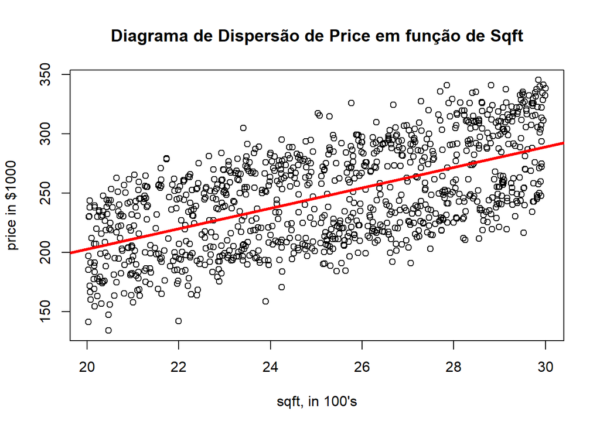

```
## integer(0)
```

```r
plot(x = utown$sqft,
     y = utown$price,
     main = "Diagrama de Dispersão de Price em função de Sqft",
     xlab = "sqft, in 100's",
     ylab = "price in $1000") +
  abline(lm(utown$price ~ utown$sqft),
         col = "red",
         lwd = 3)
```

Podemos assumir homoscedasticidade quando o termo de tem erro tem variância constante para todo valor de $X_i$. Neste modelo, aparentemente, pelo diagrama de dispersão, podemos atestar homoscedasticidade pelos pontos distribuidos de maneira uniforme ao redor da linha de regressão.

Pelo diagrama, também, observa-se que não existem muitos valores repitidos para os valores de $X$ na amostra (pontos empilhados). Portanto, assumimos que o modelo é um modelo de $X$ aleatório, e precisamos considerar, por hipótese, que $cov(X_i, u_i) = 0$ para que tenhamos um Modelo Clássico de Regressão Linear. Em outras palavras, a validade do Teorema de Gauss-Markov, e portanto da eficiência de MQO, depende da validade desta hipótese.